# Visualizing Violent Crime in Washington, D.C.

## Course: Visual Analytics for Policy and Management

### Maria Zepeda Flores, Quinn Ziegler, and Joshua Jenkins

For this project, we are interested in exploring violent crime in Washington, D.C. Crime data on all reported crimes in Washington, D.C. in 2017 were obtained from the Metropolitan Police Department. Data on census tract characteristics, including median household income, unemployment rate, and vacancy rate, were obtained from the U.S. Census Bureau 2016 Community Survey 5-Year Estimates. To combine these datasets, census tract characteristics were merged to each reported crime record based on the census tract in which the crime occured.

### Introduction

To begin, we import all of the libraries we will need for this tutorial.

```r
library(ggplot2)
library(GGally)
library(cluster)
library(dplyr)
library(broom)
library(dotwhisker)
library(ggrepel)
library(tmap)
library(tmaptools)
library(rmapshaper)
library(RColorBrewer)
library(classInt)
library(raster)
library(rgdal)
library(utils)
```

We then import the data and store it as a data frame. Note that we tell R to import any string fields as character values and not as factors.

```r
data_link = "https://github.com/qziegler/visual_analytics_final_project/raw/master/dc_crime_tract_demo.csv"
crimedf <- read.csv(data_link, stringsAsFactors = FALSE)
```

Next, we observe the storage type of the variables in our dataset.

```r
str(crimedf)
```

```
## 'data.frame':    33070 obs. of  32 variables:
##  $ CENSUS_TRACT        : int  100 100 100 100 100 100 100 100 100 100 ...
##  $ REPORT_DAT          : chr  "8/22/17 17:15" "3/12/17 13:15" "2/19/17 19:26" "5/23/17 21:00" ...
##  $ SHIFT               : chr  "EVENING" "DAY" "EVENING" "EVENING" ...
##  $ OFFENSE             : chr  "THEFT/OTHER" "THEFT F/AUTO" "THEFT/OTHER" "THEFT/OTHER" ...
##  $ METHOD              : chr  "OTHERS" "OTHERS" "OTHERS" "OTHERS" ...
##  $ BLOCK               : chr  "3100 - 3199 BLOCK OF M STREET NW" "2900 - 2999 BLOCK OF OLIVE STREET NW" "1000 - 1099 BLOCK OF THOMAS JEFFERSON STREET NW" "1000 - 1099 BLOCK OF THOMAS JEFFERSON STREET NW" ...
##  $ DISTRICT            : int  2 2 2 2 2 2 2 2 2 2 ...
##  $ PSA                 : int  206 206 206 206 206 206 206 206 206 206 ...
##  $ WARD                : int  2 2 2 2 2 2 2 2 2 2 ...
##  $ ANC                 : chr  "2E" "2E" "2E" "2E" ...
##  $ NEIGHBORHOOD_CLUSTER: chr  "Cluster 4" "Cluster 4" "Cluster 4" "Cluster 4" ...
##  $ BLOCK_GROUP         : chr  "000100 4" "000100 4" "000100 4" "000100 4" ...
##  $ VOTING_PRECINCT     : chr  "Precinct 5" "Precinct 5" "Precinct 5" "Precinct 5" ...
##  $ CCN                 : int  17145094 17040943 17400342 17086867 17098847 17215698 17080764 17071608 17090537 17171443 ...
```

[output cut: 18 more lines]

Looking at a quick distribution of the census tract characteristics we’re interested in, we see that the unemployment rate is in percentage form, but the vacancy rate is in decimal form. To ensure these fields are in the same units, we multiply our vacancy rate variable by 100.

```r
summary(crimedf$hh_med_income)
```

```
##    Min. 1st Qu.  Median    Mean 3rd Qu.    Max.    NA's
##   14692   42054   77609   80429  106806  235517     339
```

```r
summary(crimedf$unemp_rate)
```

```
##    Min. 1st Qu.  Median    Mean 3rd Qu.    Max.    NA's
##    0.00    4.20    8.00   10.05   15.30   48.60      83
```

```r
summary(crimedf$vacancy_rate)
```

```
##    Min. 1st Qu.  Median    Mean 3rd Qu.    Max.    NA's
## 0.00000 0.06105 0.10120 0.10430 0.14344 0.27263      83
```

```r
crimedf$vacancy_rate <- crimedf$vacancy_rate*100
```

The dataset we are working with now is a record of every reported crime in Washington, D.C. However, we are interested in what violent crime looks like by census tract. First, we get a data frame that is unique by census tract, including each of the census tract characteristics we are interested in examnining further.

```r
aggVars <- c("CENSUS_TRACT", "total_pop", "hh_med_income", "unemp_rate", "vacancy_rate")
aggdf <- crimedf[,aggVars]

aggdf <- unique(aggdf)
aggdf <- aggdf[!is.na(aggdf$CENSUS_TRACT),]
```

We are then interested in preparing a dataset of the violent crime rate in each census tract. We begin by looking at what offense types are present in our data.

```r
table(crimedf$OFFENSE, useNA = "always")
```

```
##
##                      ARSON ASSAULT W/DANGEROUS WEAPON
##                          4                       1851
##                   BURGLARY                   HOMICIDE
##                       1525                        115
##        MOTOR VEHICLE THEFT                    ROBBERY
##                       2411                       2170
##                  SEX ABUSE               THEFT F/AUTO
##                        290                      10256
##                THEFT/OTHER                       <NA>
##                      14448                          0
```

After determining which offense types constitute violent crime, we create a binary indicator indicating whether each record is a violent crime or not.

```r
violent_crimes <- c("ARSON", "ASSAULT W/DANGEROUS WEAPON", "HOMICIDE", "ROBBERY", "SEX ABUSE")

crimedf$violent_crime <- ifelse(crimedf$OFFENSE %in% violent_crimes, 1, 0)
```

We then aggregate the count (sum) of violent crimes by census tract and conduct a 1:1 merge of this dataset and the dataset with containing tract-level data on household median income, the unemployment rate, and the vacancy rate. As a final step, we construct the violent crime rate for each census tract, which is the number of violent crimes reported per 100,000 residents, and observe our data.

```r
census_vc  <- aggregate(violent_crime ~ CENSUS_TRACT, data = crimedf, sum)

census_violent <- merge(aggdf, census_vc, by="CENSUS_TRACT")

census_violent$vcrate <- (census_violent$violent_crime/census_violent$total_pop)*100000
head(census_violent)
```

```
##   CENSUS_TRACT total_pop hh_med_income unemp_rate vacancy_rate
## 1          100      5005        167188        4.2    16.587356
## 2          201      3733            NA        6.6     0.000000
## 3          202      4417        161378        4.7    14.370610
## 4          300      6139        131127        2.1     2.229055
## 5          400      1607        181406        0.5    10.788382
## 6          501      3481        102398        2.4     8.368201
##   violent_crime    vcrate
## 1             7 139.86014
## 2             2  53.57621
## 3            29 656.55422
## 4             9 146.60368
## 5             0   0.00000
## 6             7 201.09164
```

### Univariate Plot

Let’s start by taking a look at the distribution of violent crime rate among census tracts in Washington, D.C. We see that there are several outliers and one extreme outlier! What is going on here?

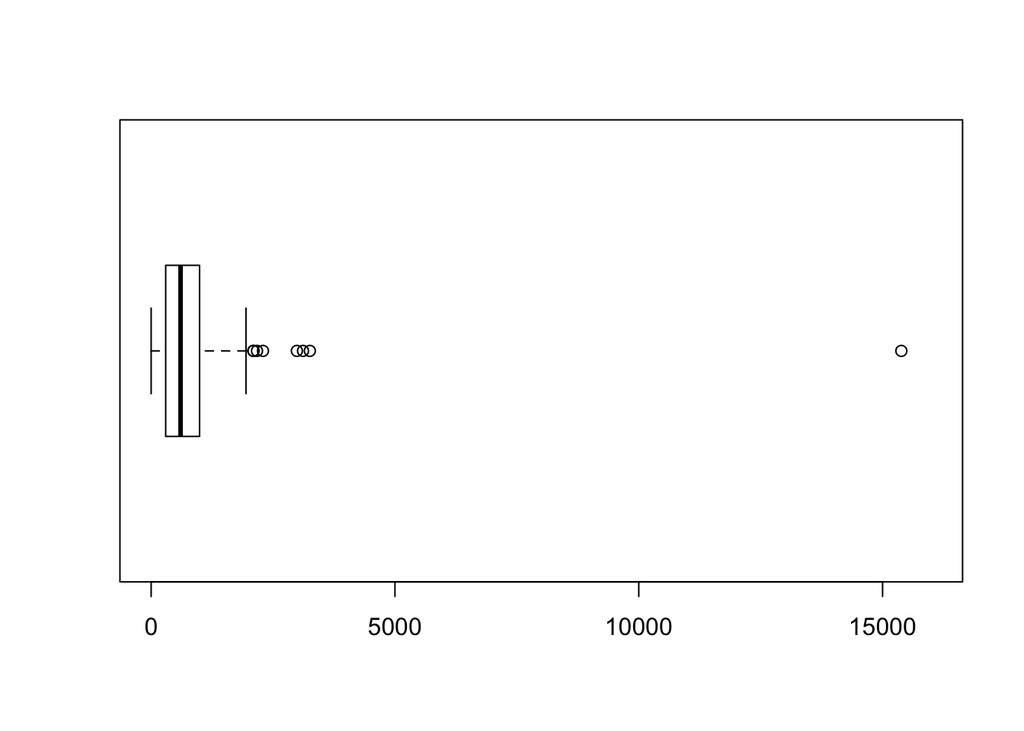

```r
bp = boxplot(census_violent$vcrate,horizontal = T,ylim=c(0,16000))
```

Here we get a list of the outlier violent crime rates. Most outliers have a violent crime rate between 2,000-3,000, but one has a violent crime rate over 15,000.

```r
bp$out
```

```
## [1]  2094.619 15384.615  2098.849  2292.959  2170.849  3114.334  2988.048
## [8]  3253.922
```

We see the extreme outlier is census tract 6202, which represents the National Mall. There are relatively few violent crimes there (only 10), but because very few people live in the area, the violent crime rate explodes.

```r
print(census_violent[(census_violent$vcrate > 15000), c("CENSUS_TRACT", "violent_crime", "total_pop", "vcrate")])
```

```
##    CENSUS_TRACT violent_crime total_pop   vcrate
## 80         6202            10        65 15384.62
```

The National Mall is a unique place in Washington, D.C. and unlike any other census tract so let’s exclude it from our data frame of violent crime and define outliers as the other tracts identified from our initial boxplot.

```r
census_violent <- census_violent[census_violent$vcrate < 15000,]
outliers <- census_violent$CENSUS_TRACT[census_violent$vcrate %in% bp$out]
outliers
```

```
## [1]  5800  7406  7803  7804  8803  9603 10700
```

However, the initial boxplot could use a little cleaning up. Below, we reproduce our boxplot, but using our new dataset excluding the National Mall. We add the coord_flip() command to flip our plot horiztonally.

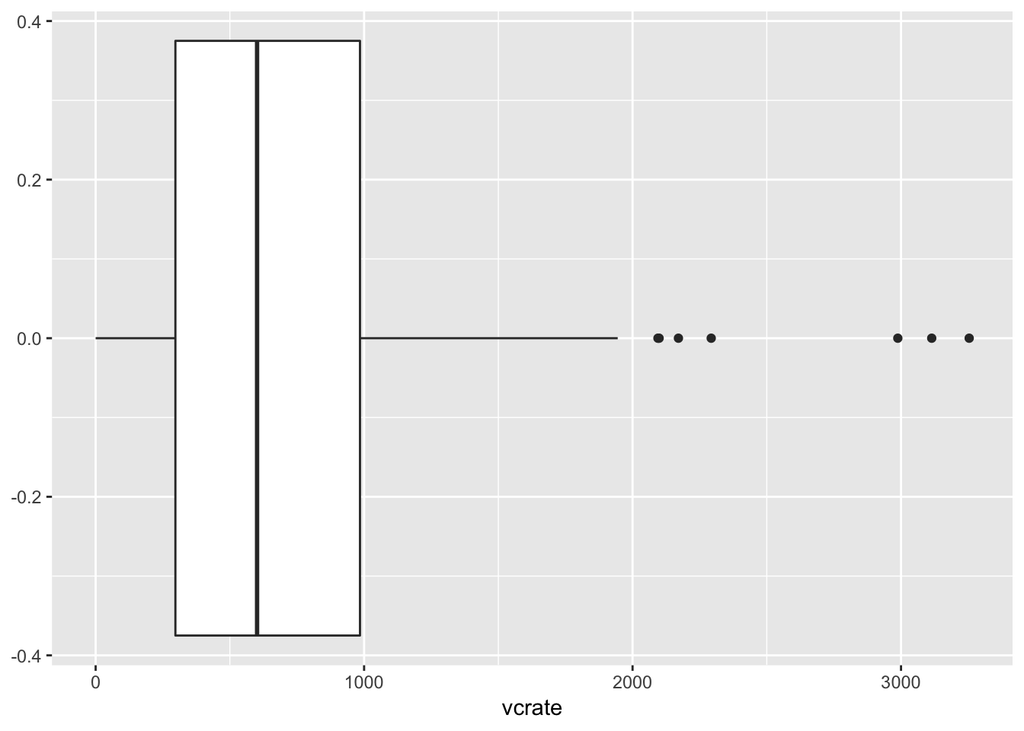

```r
boxVC = ggplot(census_violent, aes(y=vcrate, z="Test"))

boxVC = boxVC + geom_boxplot() + coord_flip()
boxVC
```

That’s a good start, but let’s add a title, a label for the x-axis, and a caption noting the source of our data. Let’s also get rid of the y-axis, since it’s meaningless, and add some other formatting to make the plot look a bit nicer.

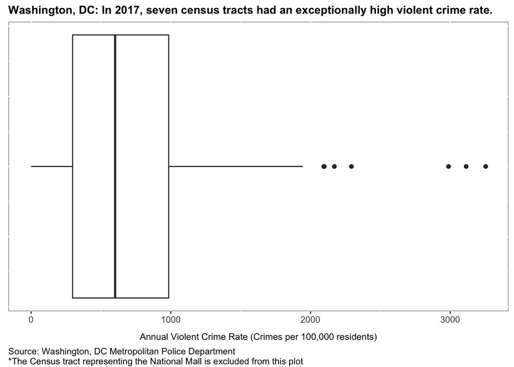

```r
box_title = "Washington, DC: In 2017, seven census tracts had an exceptionally high violent crime rate."
box_caption = "Source: Washington, DC Metropolitan Police Department \n*The Census tract representing the National Mall is excluded from this plot"

boxVC1 = boxVC + labs(title = box_title,
                      y = "Annual Violent Crime Rate (Crimes per 100,000 residents)",
                      caption = box_caption )

boxVC2 = boxVC1 + theme(panel.background = element_rect(fill = "white", color = "grey50"),
                        axis.title.x = element_text(size = 9, vjust = -1),
                        axis.text.y = element_blank(),
                        axis.ticks.y = element_blank(),
                        plot.title = element_text(size = 11, face = "bold"),
                        plot.caption = element_text(hjust = 0, vjust = -1))
boxVC2
```

As a final step, we add a note identifying which tracts make up our group of outliers. We see that there are seven tracts that fall above the distribution given by the boxplot.

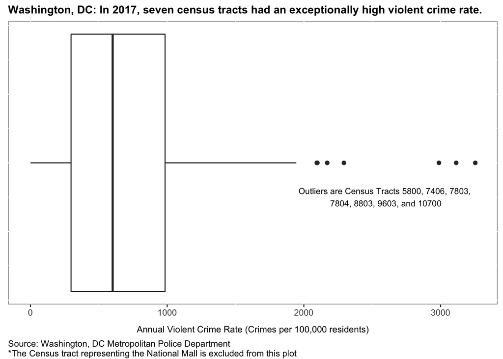

```r
box_label = "Outliers are Census Tracts 5800, 7406, 7803, \n7804, 8803, 9603, and 10700"
boxVC3 = boxVC2 + annotate("text", x = -0.1, y = 2600,
                           label = box_label,
                           size = 3) +
                  theme(axis.title.y = element_blank())

boxVC3
```

### Bivariate Plot

Next, let’s zoom in on the violent crimes happening in those seven census tract outliers. First, let’s create a data frame of all violent crimes occuring in our census tract outlier group.

```r
outliersdf = crimedf[(crimedf$CENSUS_TRACT) %in% outliers & (crimedf$violent_crime == 1),]
```

```r
CrimeType=table(outliersdf$CENSUS_TRACT, outliersdf$OFFENSE) %>%
         prop.table(margin = 2) %>%
         "*"(100) %>%
         round(3)

df.T=as.data.frame(CrimeType)
names(df.T)=c('CensusTract','Offense','Percent')
head(df.T)
```

```
##   CensusTract                    Offense Percent
## 1        5800 ASSAULT W/DANGEROUS WEAPON   6.468
## 2        7406 ASSAULT W/DANGEROUS WEAPON   9.950
## 3        7803 ASSAULT W/DANGEROUS WEAPON  17.413
## 4        7804 ASSAULT W/DANGEROUS WEAPON  11.443
## 5        8803 ASSAULT W/DANGEROUS WEAPON  17.910
## 6        9603 ASSAULT W/DANGEROUS WEAPON  21.393
```

Let’s visualize this table by making a heatmap.

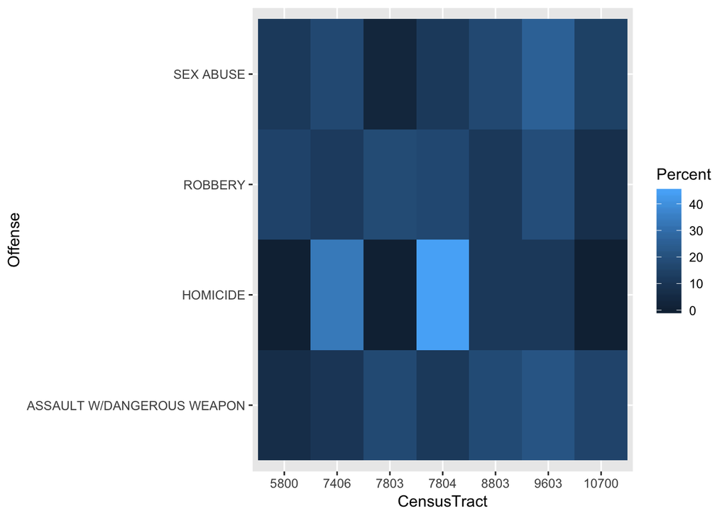

```r
base  = ggplot(df.T, aes(x = CensusTract, y = Offense, fill = Percent))

heat1 = base + geom_tile()
heat1
```

That looks okay, but the blues use a lot of ink. Also, the lighter colors suggest a higher share–perhaps it might be better if this were reversed. Let’s change the plot to black representing high shares and white representing low shares and add some formatting for the legend and x-axis.

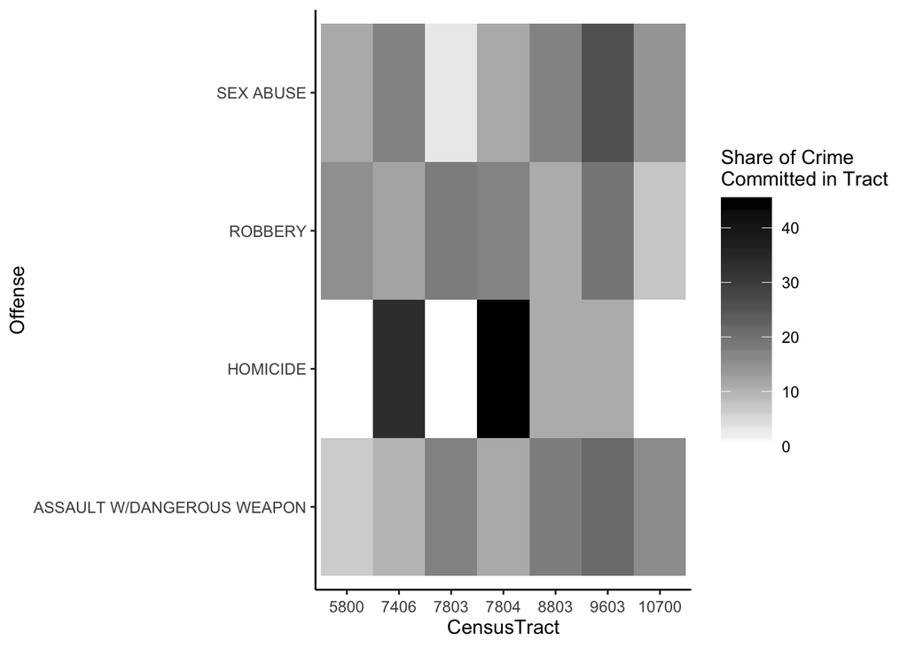

```r
heat2 = heat1 + scale_fill_gradient(low = "white", high = "black", name = "Share of Crime \nCommitted in Tract")

heat3 = heat2 + theme_classic()

heat4 = heat3 + theme(axis.text.x = element_text(angle = 0, vjust = 0.6),
                      legend.position="right",
                      legend.direction="vertical",
                      legend.key.width=unit(1, "cm"),
                      legend.key.height=unit(1, "cm"))
heat4
```

Great, now all we need is to add a title, clean up our axis titles, and add some formatting to make our plot look nice. We can see that among tracts with extreme violent crime rates, two tracts in particular account for a large share of homicides, while robberies, for example, are more equally distributed across these tracts.

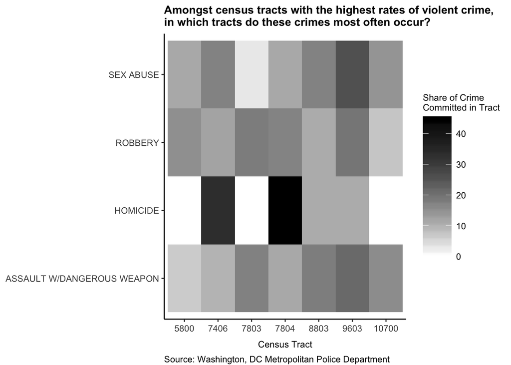

```r
heattitle = "Amongst census tracts with the highest rates of violent crime,\nin which tracts do these crimes most often occur?"
heatsource = "Source: Washington, DC Metropolitan Police Department"

heat5 = heat4 + labs(title = heattitle,
                     y="Type of Violent Crime",
                     x="Census Tract",
                     caption= "Source: Washington, DC Metropolitan Police Department")

heat6 = heat5 + theme(plot.title = element_text(face="bold", size=11),
                      plot.subtitle = element_text(size = 14, hjust = 1),
                      plot.caption = element_text(hjust = 0, vjust = -1),
                      axis.title.y = element_blank(),
                      axis.title.x = element_text(size = 9, vjust = -1),
                      legend.title = element_text(size = 9))

heat6
```

### Map

But where exactly are these outlier tracts geographically? We’ll need a map to answer this question. We start by unzipping a shape file from the U.S. Census Bureau giving up a census tract map of Washington, D.C.

```r
zipDC = "https://github.com/qziegler/visual_analytics_final_project/raw/master/2017_DCShapeFiles/tl_2017_11_tract.zip"
```

```r
temp=tempfile()
download.file(zipDC, temp)
unzip(temp)
```

We also have a shape file giving us the water in and around Washington, D.C., which will provide as a nice geographic orientation and make our map look a little nicer. Let’s unzip the needed files now as well.

```r
zipWater = "https://github.com/qziegler/visual_analytics_final_project/raw/master/2017_DCShapeFiles/tl_2017_11001_areawater.zip"
```

```r
temp=tempfile()
download.file(zipWater, temp)
unzip(temp)
```

Let’s make sure our shape files are available…

```r
(maps=list.files(pattern = 'shp'))
```

```
## [1] "tl_2017_11_tract.shp"
## [2] "tl_2017_11_tract.shp.ea.iso.xml"
## [3] "tl_2017_11_tract.shp.iso.xml"
## [4] "tl_2017_11_tract.shp.xml"
## [5] "tl_2017_11001_areawater.shp"
## [6] "tl_2017_11001_areawater.shp.ea.iso.xml"
## [7] "tl_2017_11001_areawater.shp.iso.xml"
## [8] "tl_2017_11001_areawater.shp.xml"
```

…and then import them into R.

```r
DCtractMap <- readOGR("tl_2017_11_tract.shp", stringsAsFactors = FALSE)
DCwaterMap <- readOGR("tl_2017_11001_areawater.shp", stringsAsFactors = FALSE)
```

We take a quick look at what fields are available to us. Let’s store the tract field as a numeric in case we want to merge with our other data frames that have this information stored as a numeric field.

```r
names(DCtractMap)
```

```
##  [1] "STATEFP"  "COUNTYFP" "TRACTCE"  "GEOID"    "NAME"     "NAMELSAD"
##  [7] "MTFCC"    "FUNCSTAT" "ALAND"    "AWATER"   "INTPTLAT" "INTPTLON"
```

```r
DCtractMap$TRACTCE <- as.numeric(DCtractMap$TRACTCE)
```

We’re interested in seeing where our outlier tracts are located geographically, so let’s create a layer for our map of just our outlier census tracts.

```r
tractoutliers <- DCtractMap[DCtractMap$TRACTCE %in% outliers,]
```

Now we can produce our map. We start with a map of all census tracts in Washington, D.C. as our base map.

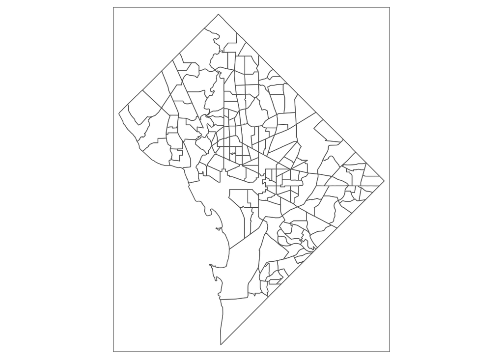

```r
base = tm_shape(DCtractMap) + tm_polygons(col = "white")
base
```

Then, we add the layer of only census tract outliers on top, coloring them black so they stand out but also minimizing the ink we use. Next, we add our water later for aesthetics.

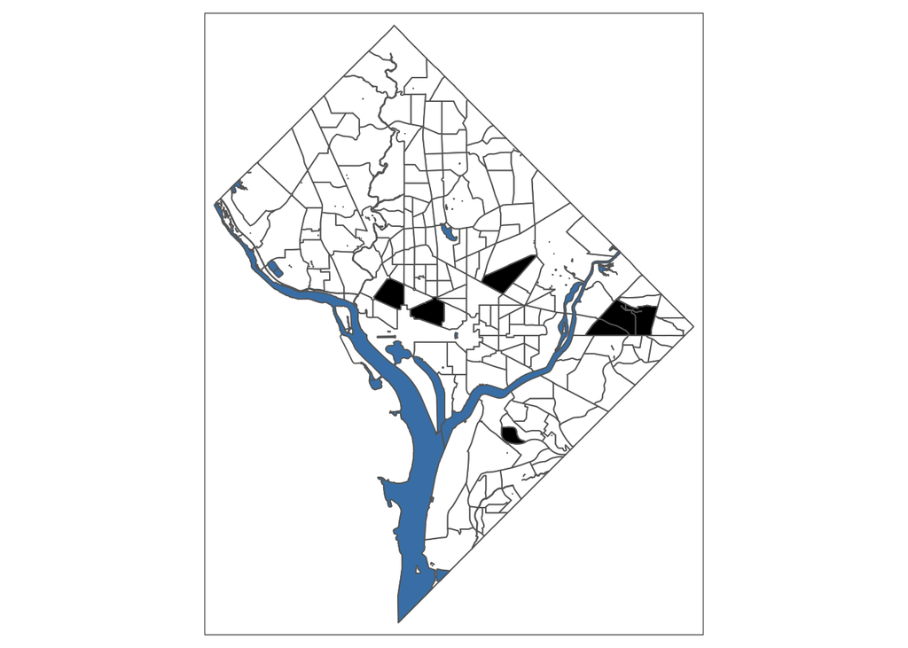

```r
layer1 = base +  tm_shape(tractoutliers) + tm_polygons(col = "black")

layer2 = layer1 + tm_shape(DCwaterMap) + tm_polygons(col="steelblue")
layer2
```

Finally, let’s add a compass and scale bar, as well as title of what the map shows. We’ll also add some formatting to the title and map to make sure everything fits nicely.

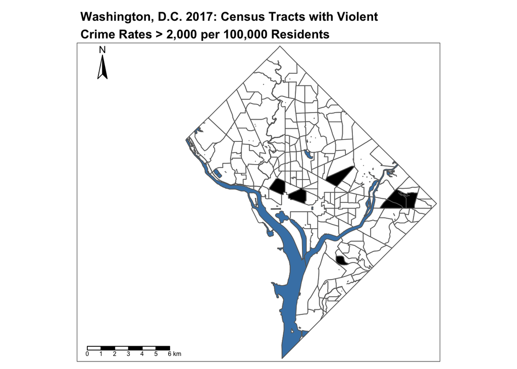

```r
fullMap = layer2 + tm_compass(position = c('left','TOP'),type = 'arrow') +
                   tm_scale_bar(position=c("left", "BOTTOM"),width = 0.2)

maptitle = "Washington, D.C. 2017: Census Tracts with Violent \nCrime Rates > 2,000 per 100,000 Residents"

fullMap = fullMap +  tm_layout(main.title = maptitle,
                     main.title.position = 'left',
                     main.title.size = 1,
                     main.title.fontface = "bold",
                     inner.margins=c(0.01,0.3,0.01,0.01))


fullMap
```